# Intro to dplyr - Lab

```r
library(tidyverse)
```

In the package `dplyr` there is a dataset called `starwars`.

```r
glimpse(starwars)
```

```
## Rows: 87
## Columns: 14
## $ name       <chr> "Luke Skywalker", "C-3PO", "R2-D2", "Darth Vader", "Leia Or…
## $ height     <int> 172, 167, 96, 202, 150, 178, 165, 97, 183, 182, 188, 180, 2…
## $ mass       <dbl> 77.0, 75.0, 32.0, 136.0, 49.0, 120.0, 75.0, 32.0, 84.0, 77.…
## $ hair_color <chr> "blond", NA, NA, "none", "brown", "brown, grey", "brown", N…
## $ skin_color <chr> "fair", "gold", "white, blue", "white", "light", "light", "…
## $ eye_color  <chr> "blue", "yellow", "red", "yellow", "brown", "blue", "blue",…
## $ birth_year <dbl> 19.0, 112.0, 33.0, 41.9, 19.0, 52.0, 47.0, NA, 24.0, 57.0, …
## $ sex        <chr> "male", "none", "none", "male", "female", "male", "female",…
## $ gender     <chr> "masculine", "masculine", "masculine", "masculine", "femini…
## $ homeworld  <chr> "Tatooine", "Tatooine", "Naboo", "Tatooine", "Alderaan", "T…
## $ species    <chr> "Human", "Droid", "Droid", "Human", "Human", "Human", "Huma…
## $ films      <list> <"The Empire Strikes Back", "Revenge of the Sith", "Return…
## $ vehicles   <list> <"Snowspeeder", "Imperial Speeder Bike">, <>, <>, <>, "Imp…
## $ starships  <list> <"X-wing", "Imperial shuttle">, <>, <>, "TIE Advanced x1",…
```

We’re going to use this to practice some data wrangling with `dplyr`.

First, we filter by species to only see the humans, and use that subset to plot a scatter plot of their height and mass.

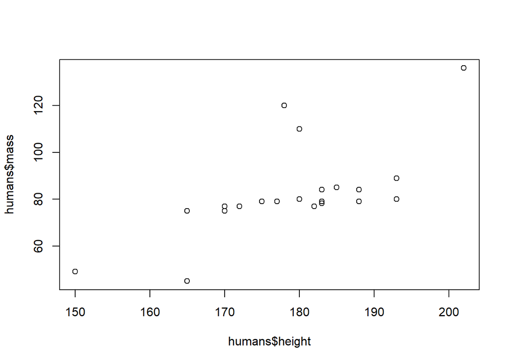

```r
humans <- starwars %>% filter(species == "Human")
plot(humans$height, humans$mass)
```

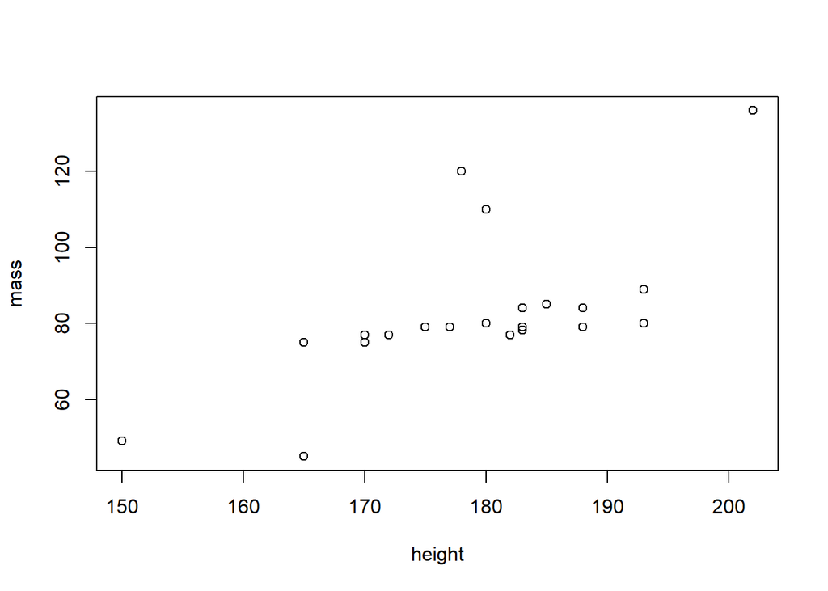

```r
starwars %>% filter(species == "Human") %>% plot(mass ~ height, data = .)
```

Now, change this to see the same plot for the Droids.

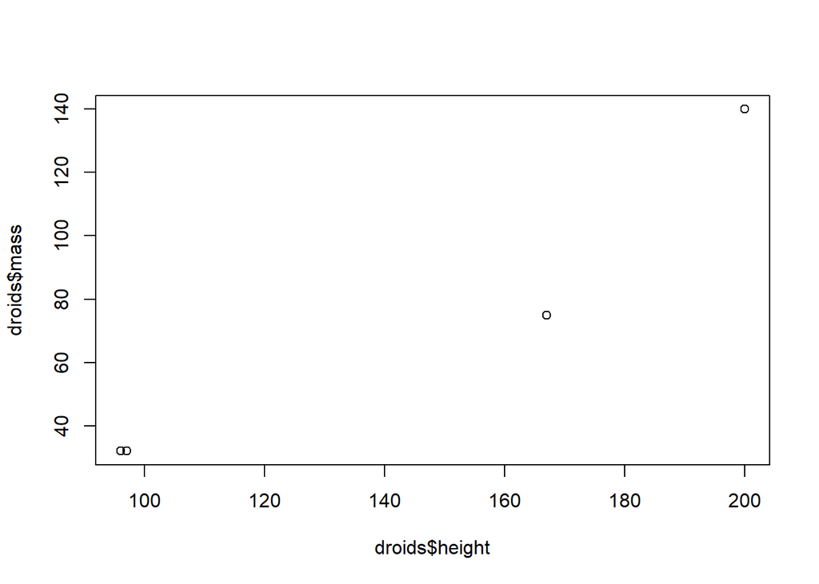

```r
droids <- starwars %>% filter(species == "Droid")
plot(droids$height, droids$mass)
```

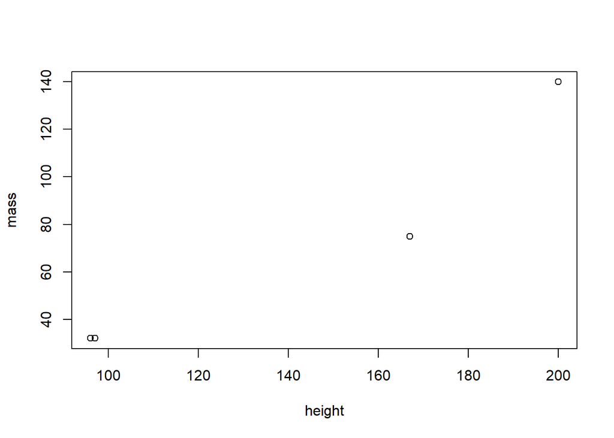

```r
starwars %>% filter(species == "Droid") %>% plot(mass ~ height, data = .)
```

How many characters are from each planet?

```r
starwars %>% group_by(homeworld) %>% count() %>% arrange(desc(n))
```

```
## # A tibble: 49 × 2
## # Groups:   homeworld [49]
##    homeworld     n
##    <chr>     <int>
##  1 Naboo        11
##  2 Tatooine     10
##  3 <NA>         10
##  4 Alderaan      3
##  5 Coruscant     3
##  6 Kamino        3
##  7 Corellia      2
##  8 Kashyyyk      2
##  9 Mirial        2
## 10 Ryloth        2
## # … with 39 more rows
```

If you wanted to arrange this in descending order, what would you add to the pipe?

```r
starwars %>% group_by(homeworld) %>% count() %>% arrange(desc(n))
```

```
## # A tibble: 49 × 2
## # Groups:   homeworld [49]
##    homeworld     n
##    <chr>     <int>
##  1 Naboo        11
##  2 Tatooine     10
##  3 <NA>         10
##  4 Alderaan      3
##  5 Coruscant     3
##  6 Kamino        3
##  7 Corellia      2
##  8 Kashyyyk      2
##  9 Mirial        2
## 10 Ryloth        2
## # … with 39 more rows
```

Find the average height for each eye color.

```r
starwars %>% group_by(eye_color) %>% summarize(average_height = mean(height))
```

```
## # A tibble: 15 × 2
##    eye_color     average_height
##    <chr>                  <dbl>
##  1 black                    NA
##  2 blue                    182.
##  3 blue-gray               182
##  4 brown                    NA
##  5 dark                     NA
##  6 gold                    191
##  7 green, yellow           216
##  8 hazel                    NA
##  9 orange                  180.
## 10 pink                    180
## 11 red                     155.
## 12 red, blue                96
## 13 unknown                  NA
## 14 white                   178
## 15 yellow                  178.
```

What’s with the NAs? Filter down to just brown eyes find out.

```r
starwars %>% filter(eye_color == "brown")
```

```
## # A tibble: 21 × 14
##    name        height  mass hair_…¹ skin_…² eye_c…³ birth…⁴ sex   gender homew…⁵
##    <chr>        <int> <dbl> <chr>   <chr>   <chr>     <dbl> <chr> <chr>  <chr>
##  1 Leia Organa    150  49   brown   light   brown      19   fema… femin… Aldera…
##  2 Biggs Dark…    183  84   black   light   brown      24   male  mascu… Tatooi…
##  3 Han Solo       180  80   brown   fair    brown      29   male  mascu… Corell…
##  4 Yoda            66  17   white   green   brown     896   male  mascu… <NA>
##  5 Boba Fett      183  78.2 black   fair    brown      31.5 male  mascu… Kamino
##  6 Lando Calr…    177  79   black   dark    brown      31   male  mascu… Socorro
##  7 Arvel Cryn…     NA  NA   brown   fair    brown      NA   male  mascu… <NA>
##  8 Wicket Sys…     88  20   brown   brown   brown       8   male  mascu… Endor
##  9 Quarsh Pan…    183  NA   black   dark    brown      62   <NA>  <NA>   Naboo
## 10 Shmi Skywa…    163  NA   black   fair    brown      72   fema… femin… Tatooi…
## # … with 11 more rows, 4 more variables: species <chr>, films <list>,
## #   vehicles <list>, starships <list>, and abbreviated variable names
## #   ¹hair_color, ²skin_color, ³eye_color, ⁴birth_year, ⁵homeworld
```

Okay, so we have missing data here. Try summarising with `na.omit(height)` instead of just `height` or adding `na.rm = T` to the mean function inside summarize.

```r
starwars %>% group_by(eye_color) %>% summarize(average_height = mean(na.rm = T, height))
```

```
## # A tibble: 15 × 2
##    eye_color     average_height
##    <chr>                  <dbl>
##  1 black                   185
##  2 blue                    182.
##  3 blue-gray               182
##  4 brown                   166.
##  5 dark                    NaN
##  6 gold                    191
##  7 green, yellow           216
##  8 hazel                   174
##  9 orange                  180.
## 10 pink                    180
## 11 red                     155.
## 12 red, blue                96
## 13 unknown                 136
## 14 white                   178
## 15 yellow                  178.
```

```r
starwars %>% group_by(eye_color) %>% summarize(average_height = mean(na.omit(height)))
```

```
## # A tibble: 15 × 2
##    eye_color     average_height
##    <chr>                  <dbl>
##  1 black                   185
##  2 blue                    182.
##  3 blue-gray               182
##  4 brown                   166.
##  5 dark                    NaN
##  6 gold                    191
##  7 green, yellow           216
##  8 hazel                   174
##  9 orange                  180.
## 10 pink                    180
## 11 red                     155.
## 12 red, blue                96
## 13 unknown                 136
## 14 white                   178
## 15 yellow                  178.
```

So, who is the tallest male? How many blue eyed women are there? How many genders are there? Answer these questions and spend some time asking and answering some of your own.

```r
starwars %>% filter(gender == "masculine") %>% arrange(desc(height))
```

```
## # A tibble: 66 × 14
##    name        height  mass hair_…¹ skin_…² eye_c…³ birth…⁴ sex   gender homew…⁵
##    <chr>        <int> <dbl> <chr>   <chr>   <chr>     <dbl> <chr> <chr>  <chr>
##  1 Yarael Poof    264    NA none    white   yellow     NA   male  mascu… Quermia
##  2 Tarfful        234   136 brown   brown   blue       NA   male  mascu… Kashyy…
##  3 Lama Su        229    88 none    grey    black      NA   male  mascu… Kamino
##  4 Chewbacca      228   112 brown   unknown blue      200   male  mascu… Kashyy…
##  5 Roos Tarpa…    224    82 none    grey    orange     NA   male  mascu… Naboo
##  6 Grievous       216   159 none    brown,… green,…    NA   male  mascu… Kalee
##  7 Rugor Nass     206    NA none    green   orange     NA   male  mascu… Naboo
##  8 Tion Medon     206    80 none    grey    black      NA   male  mascu… Utapau
##  9 Darth Vader    202   136 none    white   yellow     41.9 male  mascu… Tatooi…
## 10 IG-88          200   140 none    metal   red        15   none  mascu… <NA>
## # … with 56 more rows, 4 more variables: species <chr>, films <list>,
## #   vehicles <list>, starships <list>, and abbreviated variable names
## #   ¹hair_color, ²skin_color, ³eye_color, ⁴birth_year, ⁵homeworld
```

```r
starwars %>% filter(gender == "feminine", eye_color == "blue") %>% count()
```

```
## # A tibble: 1 × 1
##       n
##   <int>
## 1     6
```

```r
starwars %>% count(gender)
```

```
## # A tibble: 3 × 2
##   gender        n
##   <chr>     <int>
## 1 feminine     17
## 2 masculine    66
## 3 <NA>          4
```